# Predicting Stress Level

PSTAT 131 Final Project

Ivan Luc

2024-12-8

# Source

This dataset was downloaded from Kaggle, titled [“Sleep Health and Lifestyle Dataset”](https://www.kaggle.com/datasets/uom190346a/sleep-health-and-lifestyle-dataset/data).

# Introduction

The purpose of this project is to predict the stress level of individuals utilizing data collected from various aspects of their day to day lives. The dataset is synthetic, meaning that the author created it themselves simply for model testing purposes and minimizes potential bias from self-reported data for models to better capture relationships. Stress level will be what we call a target or response variable which is what we are trying to predict, and we will identify the predictor variables we want to include, which will contribute to the outcome of our response variable. Several regression models will be employed since our response variable is numeric.

## Why?

As someone trying to improve on lifestyle habits from a proper sleep schedule to getting the exercise I need to benefit my health, I’ve contemplated how such factors can influence other parts of my daily life. It’s important to recognize any patterns to help develop better habits and understand how consequences may arise by being neglectful. For example, having less sleep could contribute to a higher level of stress throughout the day, and lacking exercise could be related to a higher blood pressure. This project serves to draw attention to potential influential factors and their relationship to the identified stress levels in individuals.

```r
# libraries
library(tidyverse)
library(tidymodels)
library(ggplot2)
library(kableExtra)
library(dplyr)
library(corrplot)
library(yardstick)
library(vip)
```

# Load Data

```r
# load and display data
sleep_data <- read.csv("sleep.csv")
sleep_data %>%
  head() %>%
  kable() %>%
  kable_styling(full_width = F) %>%
  scroll_box(width = "100%", height = "200px")
```

| Person.ID | Gender | Age | Occupation | Sleep.Duration | Quality.of.Sleep | Physical.Activity.Level | Stress.Level | BMI.Category | Blood.Pressure | Heart.Rate | Daily.Steps | Sleep.Disorder |
| --- | --- | --- | --- | --- | --- | --- | --- | --- | --- | --- | --- | --- |
| 1 | Male | 27 | Software Engineer | 6.1 | 6 | 42 | 6 | Overweight | 126/83 | 77 | 4200 | None |
| 2 | Male | 28 | Doctor | 6.2 | 6 | 60 | 8 | Normal | 125/80 | 75 | 10000 | None |
| 3 | Male | 28 | Doctor | 6.2 | 6 | 60 | 8 | Normal | 125/80 | 75 | 10000 | None |
| 4 | Male | 28 | Sales Representative | 5.9 | 4 | 30 | 8 | Obese | 140/90 | 85 | 3000 | Sleep Apnea |
| 5 | Male | 28 | Sales Representative | 5.9 | 4 | 30 | 8 | Obese | 140/90 | 85 | 3000 | Sleep Apnea |
| 6 | Male | 28 | Software Engineer | 5.9 | 4 | 30 | 8 | Obese | 140/90 | 85 | 3000 | Insomnia |

```r
# data dimension
dim(sleep_data)
```

```
## [1] 374  13
```

Here we can see that the dataset has a moderate size, consisting of a total of 374 observations and 13 variables.

# Tidying Data

For easier readability, let’s simplify the appearance of our variable names.

```r
# rename variables
sleep_data <- sleep_data %>%
  rename(id = Person.ID,
         gender = Gender,
         age = Age,
         occupation = Occupation,
         duration = Sleep.Duration,
         quality = Quality.of.Sleep,
         activity = Physical.Activity.Level,
         stress = Stress.Level,
         bmi = BMI.Category,
         bp = Blood.Pressure,
         hr = Heart.Rate,
         steps = Daily.Steps,
         disorder = Sleep.Disorder)
```

For our dataset to be compatible with our regression models, we need to make some adjustments to all of the character or categorical variables. These must be converted into factors so the models can interpret them as numerical levels. However for `bp`, which is also currently a character variable, we will split the strings and separate the values into `sbp` and `dbp`, or systolic blood pressure and diastolic blood pressure respectively. Then if we look at the `bmi` column values, there are “Normal Weight” values as well as “Normal” which are the same, so we will replace all instances of “Normal Weight” with “Normal”.

```r
# change character variables into factor
sleep_data$gender <- factor(sleep_data$gender)
sleep_data$occupation <- factor(sleep_data$occupation)
sleep_data$bmi <- factor(sleep_data$bmi)
sleep_data$disorder <- factor(sleep_data$disorder)

# split Blood.Pressure variable into systolic and diastolic
sleep_data <- sleep_data %>%
  separate(bp, into = c("sbp", "dbp"), sep = "/")
sleep_data$sbp <- as.integer(sleep_data$sbp)
sleep_data$dbp <- as.integer(sleep_data$dbp)

# combine Normal and Normal Weight in bmi variable
sleep_data$bmi <- gsub("Normal Weight", "Normal", sleep_data$bmi)
```

# Exploratory Data Analysis

To start, it’s important to examine and understand the contents of our data such as the dimensions, variable interpretation, and variable types. We have to look out for any missing values or inconsistencies that may affect the results produced by the models.

## Define Variables

We should define our variables to understand what we will be working with.

- `id`: unique identification number
- `gender`: gender as male or female
- `age`: age in years
- `occupation`: job
- `duration`: number of hours of sleep each day
- `quality`: quality of sleep rated on a scale of 1 to 10
- `activity`: number of minutes of physical activity each day
- `stress`: level of stress rated on a scale of 1 to 10
- `bmi`: BMI category as Normal, Overweight, and Obese
- `bp`: blood pressure shown as systolic pressure over diastolic pressure
- `hr`: heart rate in beats per minute
- `steps`: number of steps each day
- `disorder`: sleep disorder categorized as None, Insomnia, or Sleep Apnea

## Check for Missing Values

```r
# summary of all data
summary(sleep_data)
```

```
##        id            gender         age             occupation    duration
##  Min.   :  1.00   Female:185   Min.   :27.00   Nurse     :73   Min.   :5.800
##  1st Qu.: 94.25   Male  :189   1st Qu.:35.25   Doctor    :71   1st Qu.:6.400
##  Median :187.50                Median :43.00   Engineer  :63   Median :7.200
##  Mean   :187.50                Mean   :42.18   Lawyer    :47   Mean   :7.132
##  3rd Qu.:280.75                3rd Qu.:50.00   Teacher   :40   3rd Qu.:7.800
##  Max.   :374.00                Max.   :59.00   Accountant:37   Max.   :8.500
##                                                (Other)   :43
##     quality         activity         stress          bmi
##  Min.   :4.000   Min.   :30.00   Min.   :3.000   Length:374
##  1st Qu.:6.000   1st Qu.:45.00   1st Qu.:4.000   Class :character
##  Median :7.000   Median :60.00   Median :5.000   Mode  :character
##  Mean   :7.313   Mean   :59.17   Mean   :5.385
##  3rd Qu.:8.000   3rd Qu.:75.00   3rd Qu.:7.000
##  Max.   :9.000   Max.   :90.00   Max.   :8.000
##
##       sbp             dbp              hr            steps
##  Min.   :115.0   Min.   :75.00   Min.   :65.00   Min.   : 3000
##  1st Qu.:125.0   1st Qu.:80.00   1st Qu.:68.00   1st Qu.: 5600
##  Median :130.0   Median :85.00   Median :70.00   Median : 7000
##  Mean   :128.6   Mean   :84.65   Mean   :70.17   Mean   : 6817
##  3rd Qu.:135.0   3rd Qu.:90.00   3rd Qu.:72.00   3rd Qu.: 8000
##  Max.   :142.0   Max.   :95.00   Max.   :86.00   Max.   :10000
##
##         disorder
##  Insomnia   : 77
##  None       :219
##  Sleep Apnea: 78
##
##
##
##
```

Luckily there are no missing data values in the dataset so we can move forward. If missing values were to exist, in any column, there would be an ‘NA’ at the bottom of the variable column indicating the number of missing values that column has.

## Visual EDA

In this section we will visualize our variables and any relationships they may have with each other.

### Stress

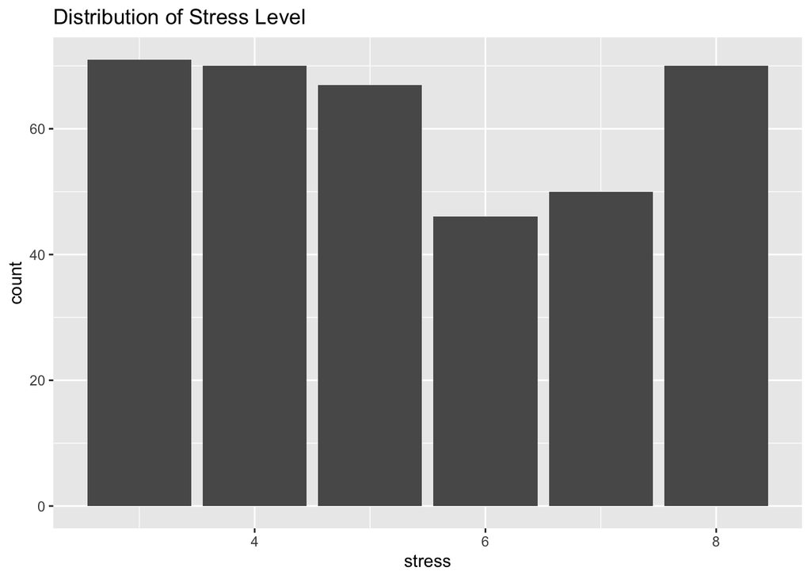

```r
# stress distribution
ggplot(sleep_data, aes(stress)) +
  geom_bar() +
  labs(title="Distribution of Stress Level")
```

Here we can see that although `stress` can range from values 1 to 10, but our dataset only consists of values 3 to 8. The `stress` levels 6 and 7 have the least frequency while the rest are quite evenly distributed with the highest being at level 3.

### Correlation Plot

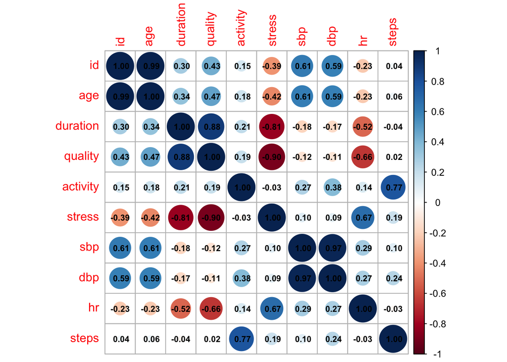

```r
# correlation plot on full data
sleep_data %>%
  select(is.numeric) %>%
  cor() %>%
  corrplot(type = 'full', diag = TRUE,
           method = 'circle', addCoef.col = 1, number.cex = 0.7)
```

In a correlation plot, we are able to see a spectrum of correlations from -1 to 1 with -1 being a complete negative correlation and 1 being a complete positive correlation. There are a few notable variable relationships that have relatively strong correlations. Our target variable `stress` and `quality` have a negative correlation of -0.90 which signifies that as `stress` increases, `quality` decreases or vice versa. This shows that the level of stress an individual maintains tends to be higher the worse their quality of sleep is. `duration` also appears to have a significant negative correlation with `stress` of -0.81 as well as a significant positive correlation with `quality` of 0.88. This suggests that `duration` and `quality` are alike and overlap in evaluating the sleeping aspect of individuals’ daily lives which also explains it’s similar relationship to `stress`. Other pairs that can be easily explained are `steps` and `activity` with a positive correlation of 0.77 and `sbp` and `dbp` with an almost pure positive correlation of 0.97. `steps` can be seen as a sub category of `activity`, and `sbp` and `dbp` were split from the same original variable.

It’s important to point out these notable relationships prior to developing our models because high correlations between predictor variables may lead to multicollinearity issues where data becomes redundant and tampers with the accuracy of regression estimates.

### Stress and Quality

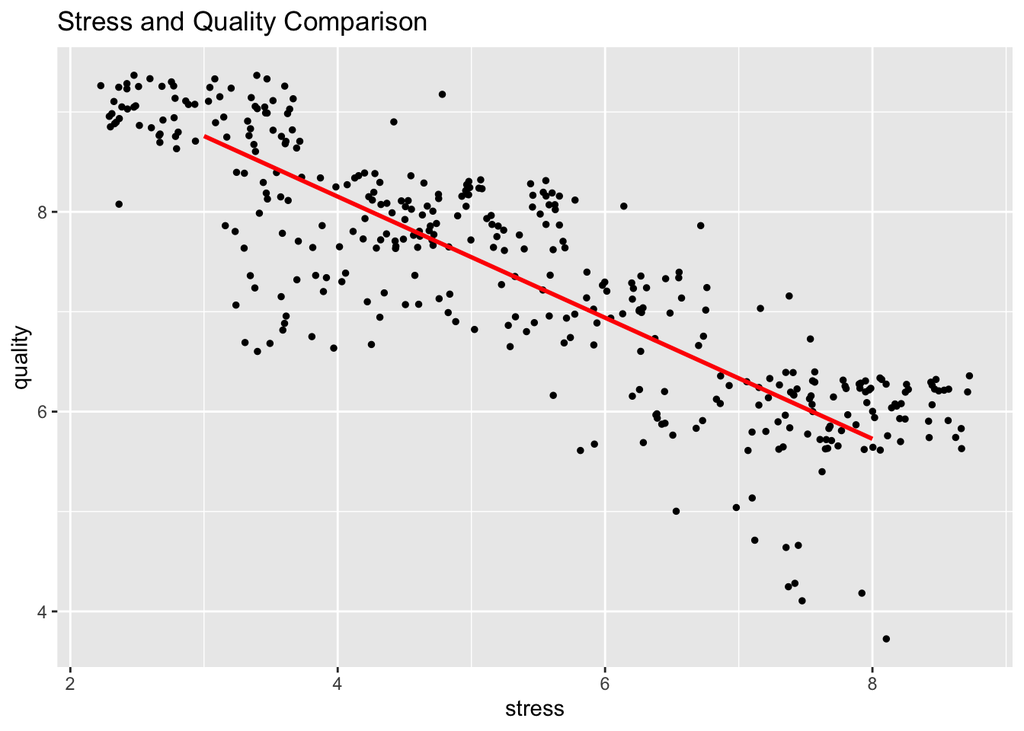

```r
sleep_data %>%
  ggplot(aes(x = stress, y = quality)) +
  geom_jitter(width = 0.8, size = 1) +
  geom_smooth(method = "lm", se = FALSE, col = "red") +
  labs(title = "Stress and Quality Comparison")
```

Since we’re focusing on `stress` as our target variable, we can plot it against `quality` since they have the strongest correlation with each other. As we can see, the scatter plot can easily be fitted with a line of best fit showing that they indeed have a significant negative correlation.

### Occupation

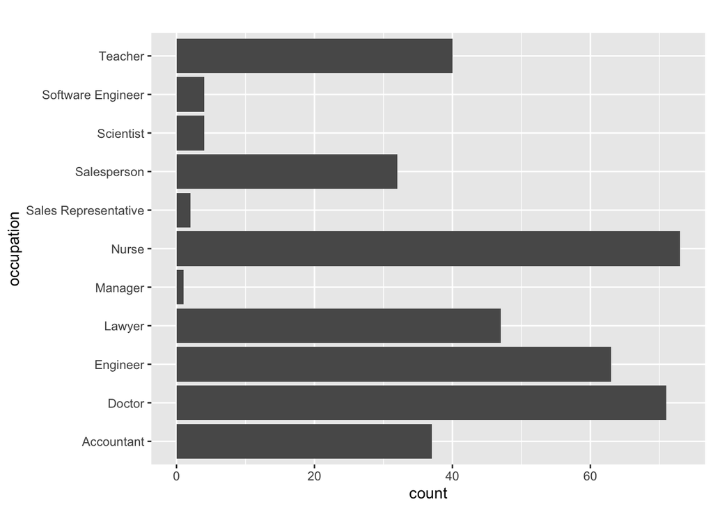

```r
sleep_data %>%
  ggplot(aes(y = occupation)) +
  geom_bar() +
  labs(title = "")
```

We can visualize the distribution of `occupation` to show the frequency of each job. We will combine all of the values with the 5 lowest frequency and lump them into a category called “Other”. This will allow for a better distribution where all values can be accounted for rather than being lost in the model training and testing process.

```r
library(forcats)
# lump variables together
sleep_data <- sleep_data %>%
  filter(!is.na(occupation)) %>%
  mutate(occupation = fct_lump(occupation, n = 6))
```

### BMI and Disorder

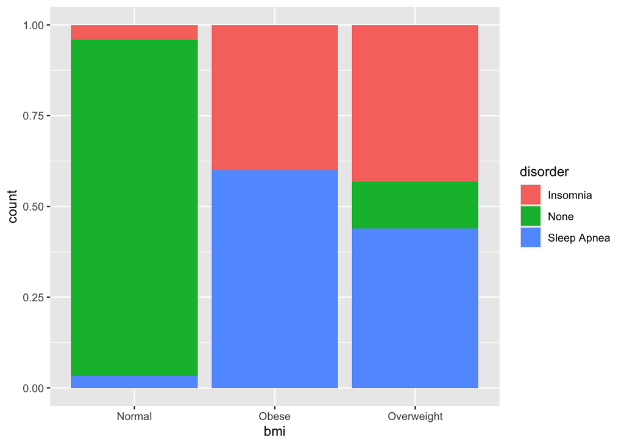

```r
ggplot(sleep_data, aes(x = bmi, fill = disorder)) +
  geom_bar(position = "fill")
```

In this plot we can view the relationship between `bmi` and `disorder` that were not represented in the correlation plot due to their categorical nature. We can observe that those with a normal BMI tend to not have any sleeping disorder while those with an obese or overweight BMI are more similar in proportions by having mostly insomnia and sleep apnea.

### BMI and Systolic Blood Pressure

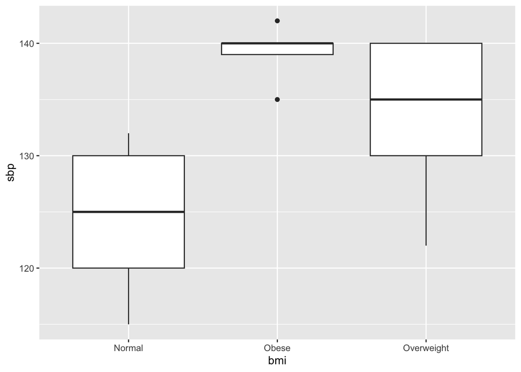

```r
ggplot(sleep_data, aes(x = bmi, y = sbp)) +
  geom_boxplot()
```

# Setting Up Models

Now we can set up our models where we will be splitting our data into training and testing sets, creating our recipe, and performing cross validation.

## Data Split

Splitting our data into training and testing sets is necessary because, as their names imply, our training set will be used to train our models and the testing set will be reserved to see how well the models perform after taking in the training set. For this project, I have chosen an 80 to 20 split with 80% of the data for training and 20% of the data for testing. This should be a sufficient proportion for each step since our overall dataset is not the largest.

```r
# split data
set.seed(22)
sleep_split <- initial_split(sleep_data, prop = 0.80, strata = quality)
sleep_train <- training(sleep_split)
sleep_test <- testing(sleep_split)
```

We can see the new dimensions and verify that the datasets are proportional to our intended split.

```r
dim(sleep_train)
```

```
## [1] 297  14
```

```r
nrow(sleep_train)/nrow(sleep_data)
```

```
## [1] 0.7941176
```

```r
dim(sleep_test)
```

```
## [1] 77 14
```

```r
nrow(sleep_test)/nrow(sleep_data)
```

```
## [1] 0.2058824
```

## Recipe Creation

Remember how we recognized that high correlation between predictor variables will results in multicollinearity? When creating our recipe we will have to decide which of our original variables we want to use as predictors and which variables we will exclude. The variables I have chosen to exclude are `id`, `dbp`, `duration`, and `activity`. `id` only serves to identify individuals so it will not have any contribution. `sbp` and `dbp` come from the same variable so we will just keep `sbp` because we only need one. Since `duration` and `quality` are highly correlated, we will choose to keep the one with a stronger correlation with `stress` which is `quality`. The same goes for `activity` and `steps` with `steps` having the stronger correlation.

```r
# create recipe
sleep_recipe <- recipe(stress ~ gender + age + occupation + quality + bmi + sbp + hr + steps + disorder, data = sleep_train) %>%
  step_dummy(gender, occupation, bmi, disorder) %>%
  step_center(all_predictors()) %>%
  step_scale(all_predictors())
```

## K-Fold Cross-Validation

In K-fold cross-validation, our dataset is split into a K number of folds of our choosing. The models will also be trained a K number of times. For each training, one fold will be designated as a testing set while the other folds are used to traing the model and each fold will get a chance to be the testing set. At the end of the process, all the metric scores for each iteration will be averaged and produce a final performance score. This process allows for a thorough utilization of the entire dataset and mitigate overfitting. For our models we will select 10 folds.

```r
# k-fold cross validation
sleep_folds <- vfold_cv(sleep_train, v = 10, strata = "stress")
```

# Model Building

We can finally begin building our models. Our metric to assess how well our models perform against each other is Root Mean Square Error (RMSE) which tells us the average distance between the predicted values and actual values. This means that the lowest score will be the best score since we are looking for the predicted values to be as close to the actual values as possible. The models I have chosen are linear regression, polynomial regression, k-nearest neighbors, random forest, decision tree, ridge regression, lasso regression, and elastic net regression.

We’ll break up the model building process into steps:

1. Define each model by selecting the type of model and specifying the engine, mode, and any parameters that the model requires.

```r
# linear regression
lm_model <- linear_reg() %>%
  set_engine("lm")

# polynomial regression
pm_model <- linear_reg() %>%
  set_engine("lm")

pm_recipe <- sleep_recipe %>%
  step_poly(age, quality, sbp, hr, steps, degree = tune())

# knn
knn_model <- nearest_neighbor(neighbors = tune()) %>%
  set_engine("kknn") %>%
  set_mode("regression")

# random forest
rf_model <- rand_forest(mtry = tune(),
                        trees = tune(),
                        min_n = tune()) %>%
  set_engine("ranger", importance = "impurity") %>%
  set_mode("regression")

# decision tree
dt_model <- decision_tree(cost_complexity = tune()) %>%
  set_engine("rpart") %>%
  set_mode("regression")

# ridge regression
r_model <- linear_reg(mixture = 0,
                      penalty = tune()) %>%
  set_engine("glmnet") %>%
  set_mode("regression")

# lasso regression
l_model <- linear_reg(mixture = 1,
                      penalty = tune()) %>%
  set_engine("glmnet") %>%
  set_mode("regression")

# elastic net regression
en_model <- linear_reg(mixture = tune(),
                      penalty = tune()) %>%
  set_engine("glmnet") %>%
  set_mode("regression")
```

2. Establish workflows by adding each respective model and applying the recipe.

```r
# linear regression
lm_wflow <- workflow() %>%
  add_model(lm_model) %>%
  add_recipe(sleep_recipe)

# polynomial regression
pm_wflow <- workflow() %>%
  add_model(pm_model) %>%
  add_recipe(pm_recipe)

# knn
knn_wflow <- workflow() %>%
  add_model(knn_model) %>%
  add_recipe(sleep_recipe)

# random forest
rf_wflow <- workflow() %>%
  add_model(rf_model) %>%
  add_recipe(sleep_recipe)

# decision tree
dt_wflow <- workflow() %>%
  add_model(dt_model) %>%
  add_recipe(sleep_recipe)

# ridge regression
r_wflow <- workflow() %>%
  add_model(r_model) %>%
  add_recipe(sleep_recipe)

# lasso regression
l_wflow <- workflow() %>%
  add_model(l_model) %>%
  add_recipe(sleep_recipe)

# lasso regression
l_wkflow <- workflow() %>%
  add_model(l_model) %>%
  add_recipe(sleep_recipe)

# elastic net regression
en_wflow <- workflow() %>%
  add_model(en_model) %>%
  add_recipe(sleep_recipe)
```

3. Create tuning grids for the models and specify their degree ranges and levels. Note that linear regression will not have a tuning grid.

```r
# polynomial regression
pm_grid <- grid_regular(degree(range = c(1,5)),
                        levels = 5)

# k-nearest neighbors
knn_grid <- grid_regular(neighbors(range = c(1,10)),
                         levels = 10)

# random forest
rf_grid <- grid_regular(mtry(range = c(1,9)),
                        trees(range = c(100,800)),
                        min_n(range = c(5,40)),
                        levels = 8)

# decision tree
dt_grid <- grid_regular(cost_complexity(range = c(-10,0)),
                        levels = 20)

# ridge regression
r_grid <- grid_regular(penalty(range = c(-5,0)),
                       levels = 10)

# lasso regression
l_grid <- grid_regular(penalty(range = c(-5,0)),
                       levels = 10)

# elastic net regression
en_grid <- grid_regular(mixture(range = c(0,1)),
                        penalty(range = c(0, 1), trans = identity_trans()),
                        levels = 10)
```

4. Tune each model with their respective tuning grids and apply the k-fold cross validation folds.

```r
# linear regression
lm_fit <- fit_resamples(lm_wflow, resamples = sleep_folds)

# polynomial regression
pm_tune <- tune_grid(pm_wflow, resamples = sleep_folds,
                       grid = pm_grid)

# k-nearest neighbors
knn_tune <- tune_grid(knn_wflow, resamples = sleep_folds,
                       grid = knn_grid)

# random forest
rf_tune <- tune_grid(rf_wflow, resamples = sleep_folds,
                       grid = rf_grid)

# decision tree
dt_tune <- tune_grid(dt_wflow, resamples = sleep_folds,
                       grid = dt_grid)

# ridge regression
r_tune <- tune_grid(r_wflow, resamples = sleep_folds,
                       grid = r_grid)

# lasso regression
l_tune <- tune_grid(l_wflow, resamples = sleep_folds,
                       grid = l_grid)

# elastic net regression
en_tune <- tune_grid(en_wflow, resamples = sleep_folds,
                       grid = en_grid)
```

5. Collect the final results, retrieve and sort all the RMSE scores, and extract the lowest score of each model.

```r
# linear regression
lm_collect <- collect_metrics(lm_fit) %>%
  filter(.metric == "rmse")
lm_rmse <- lm_collect$mean[1]

# polynomial regression
pm_collect <- collect_metrics(pm_tune) %>%
  filter(.metric == "rmse") %>%
  arrange(mean)
pm_rmse <- pm_collect$mean[1]

# k-nearest neighbors
knn_collect <- collect_metrics(knn_tune) %>%
  filter(.metric == "rmse") %>%
  arrange(mean)
knn_rmse <- knn_collect$mean[1]

# random forest
rf_collect <- collect_metrics(rf_tune) %>%
  filter(.metric == "rmse") %>%
  arrange(mean)
rf_rmse <- rf_collect$mean[1]

# decision tree
dt_collect <- collect_metrics(dt_tune) %>%
  filter(.metric == "rmse") %>%
  arrange(mean)
dt_rmse <- dt_collect$mean[1]

# ridge regression
r_collect <- collect_metrics(r_tune) %>%
  filter(.metric == "rmse") %>%
  arrange(mean)
r_rmse <- r_collect$mean[1]

# lasso regression
l_collect <- collect_metrics(l_tune) %>%
  filter(.metric == "rmse") %>%
  arrange(mean)
l_rmse <- l_collect$mean[1]

# elastic net regression
en_collect <- collect_metrics(en_tune) %>%
  filter(.metric == "rmse") %>%
  arrange(mean)
en_rmse <- en_collect$mean[1]
```

# Results

Here are all the results for the models.

```r
# display rmse scores
table <- data.frame(
  Model = c("Linear Regression", "Polynomial Regression", "K-Nearest Neighbors", "Random Forest", "Decision Tree", "Ridge Regression", "Lasso Regression", "Elastic Net Regression"),
  RMSE = c(lm_rmse, pm_rmse, knn_rmse, rf_rmse, dt_rmse, r_rmse, l_rmse, en_rmse)
) %>%
  arrange(RMSE)
print(table)
```

```
##                    Model      RMSE
## 1          Random Forest 0.2566811
## 2    K-Nearest Neighbors 0.3346165
## 3          Decision Tree 0.3548446
## 4  Polynomial Regression 0.3973926
## 5       Lasso Regression 0.4238244
## 6 Elastic Net Regression 0.4239963
## 7      Linear Regression 0.4247405
## 8       Ridge Regression 0.4974073
```

Let’s put these results into a bar plot to better visualize and compare them.

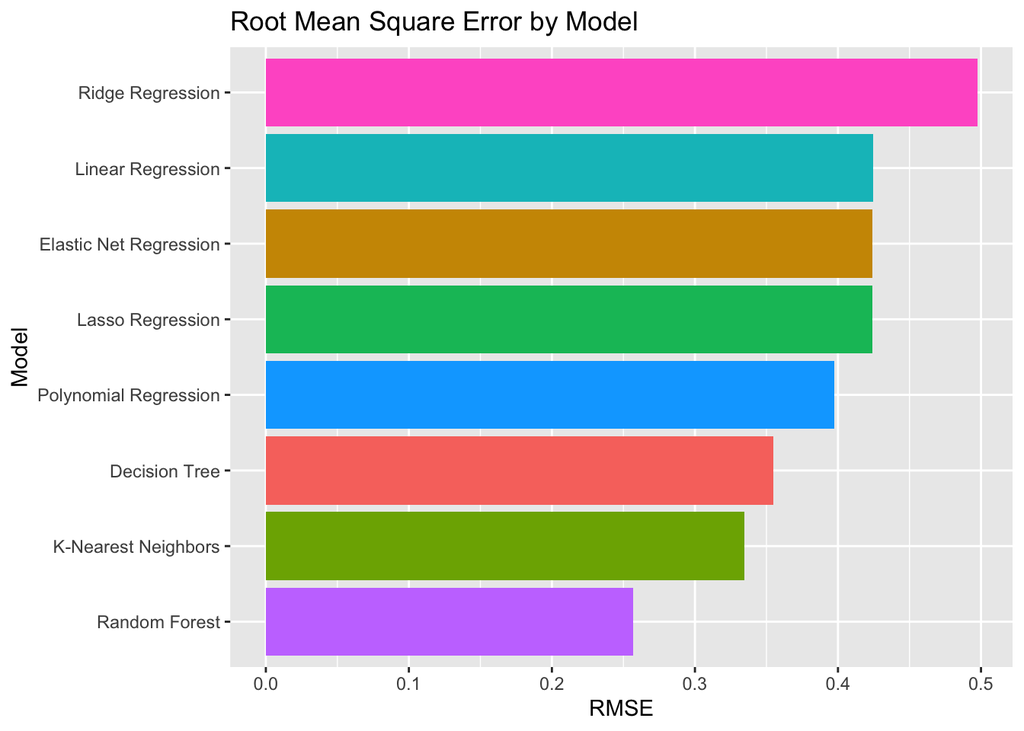

```r
# bar plot
ggplot(table, aes(x = reorder(Model, RMSE), y = RMSE, fill = Model)) +
  geom_bar(stat = "identity") +
  labs(title = "Root Mean Square Error by Model",
       x = "Model",
       y = "RMSE") +
  coord_flip() +
  theme(legend.position = "none")
```

We can very well see that random forest outperforms the rest of the for this particular dataset. In second and third place we have k-nearest neighbors followed by decision tree. Some observations we can make are that ridge regression is the opposite by performing the worst, and linear, elastic net, and lasso regression are almost identical to each other in performance. Note that the values are quite small due to the range of values for `stress` only being 1 to 10.

## Random Forest

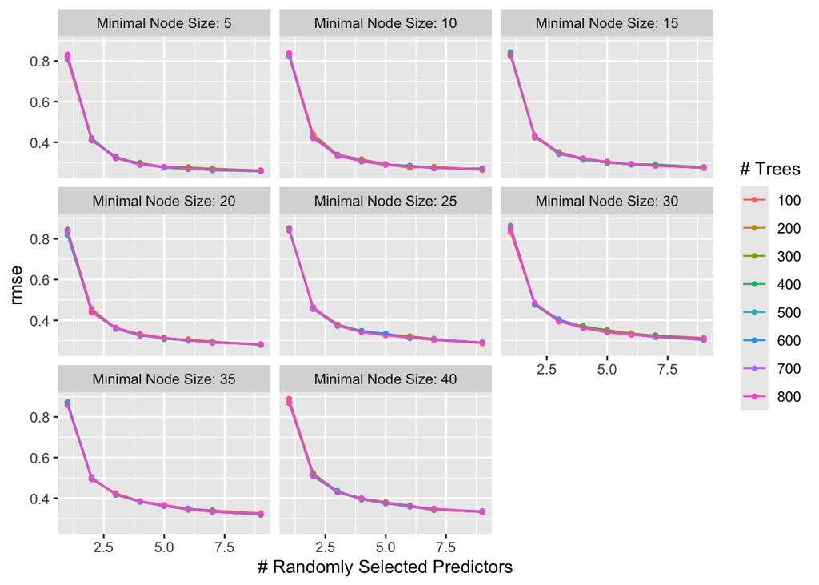

```r
# autoplots
autoplot(rf_tune, metric = 'rmse')
```

For our random forest model we can see multiple graphs to show the three parameters we tuned which were mtry, trees, and min_n. mtry is the number of predictors to be split at each node, min_n is the minimum node size, and trees is the total number of trees in the forest. We can see that rmse value of each model has a sharp decline at the start and gradually decreases. The number of trees does not seem to have any effect as the trend within each graph tends to stay the same being stacked on top of one another. The min_n value of 5 seems to produce the lowest rmse score with the rmse only increaseing as min_n increases.

## K-Nearest Neighbors

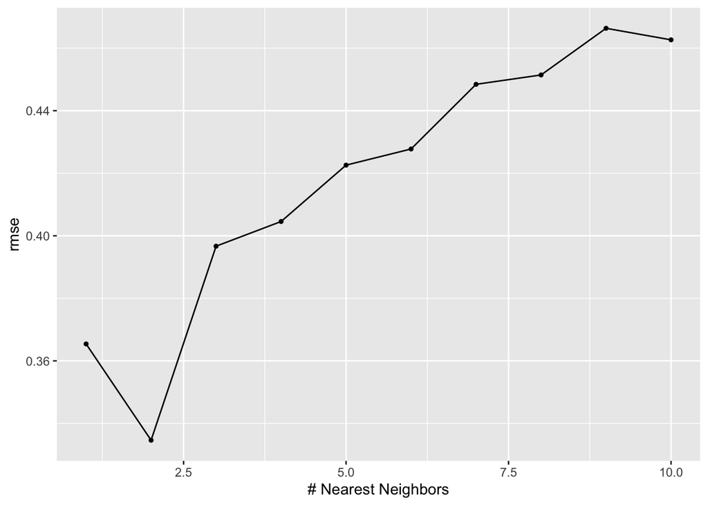

```r
autoplot(knn_tune, metric = 'rmse')
```

For our k-nearest neighbors model, we only tuned one parameter which was a range of neighbors from 1 to 10. The number of neighbors specifies the number of data points considered when predicting the new value. Interestingly, the rmse score decreases when the number of nearest neighbors approaches 2.5 but only increases afterwards.

## Decision Tree

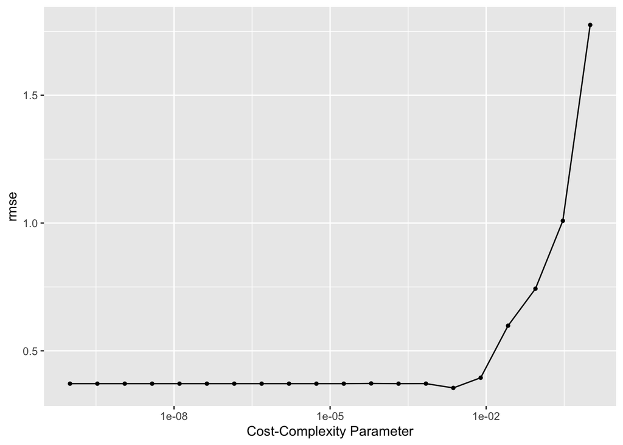

```r
autoplot(dt_tune, metric = 'rmse')
```

For our decision tree model, we only had to tune the cost_complexity parameter set from -10 to 0. The cost_complexity represents the trade off between the error or cost and the size or complexity of the tree. It appears that the rmse value remains stagnant until it makes a sharp increase at the end around cost_complexity of -2.

# Final Testing with Best Model

## Best Parameters

Let’s take a look at the best parameters that put random forest in the top spot against the rest of the models.

```r
# best parameters for random forest
show_best(rf_tune, metric="rmse", n = 1)
```

```
## # A tibble: 1 × 9
##    mtry trees min_n .metric .estimator  mean     n std_err .config
##   <int> <int> <int> <chr>   <chr>      <dbl> <int>   <dbl> <chr>
## 1     9   100     5 rmse    standard   0.257    10  0.0624 Preprocessor1_Model0…
```

## Fit and Test Model

We will use these parameters and fit them into the training data.

```r
# test random forest
best_params <- select_best(rf_tune, metric = "rmse")
final_wflow <- finalize_workflow(rf_wflow, best_params)
final_rf_model <- fit(final_wflow, data = sleep_train)

test_predictions <- predict(final_rf_model, new_data = sleep_test)

final_rf_model_test <- sleep_test %>%
  mutate(.pred = test_predictions$.pred) %>%
  select(stress, .pred)

sleep_metric <- metric_set(rmse)
rf_metric <- sleep_metric(final_rf_model_test, truth = stress, estimate = .pred)
print(rf_metric)
```

```
## # A tibble: 1 × 3
##   .metric .estimator .estimate
##   <chr>   <chr>          <dbl>
## 1 rmse    standard       0.234
```

## Visualize Results

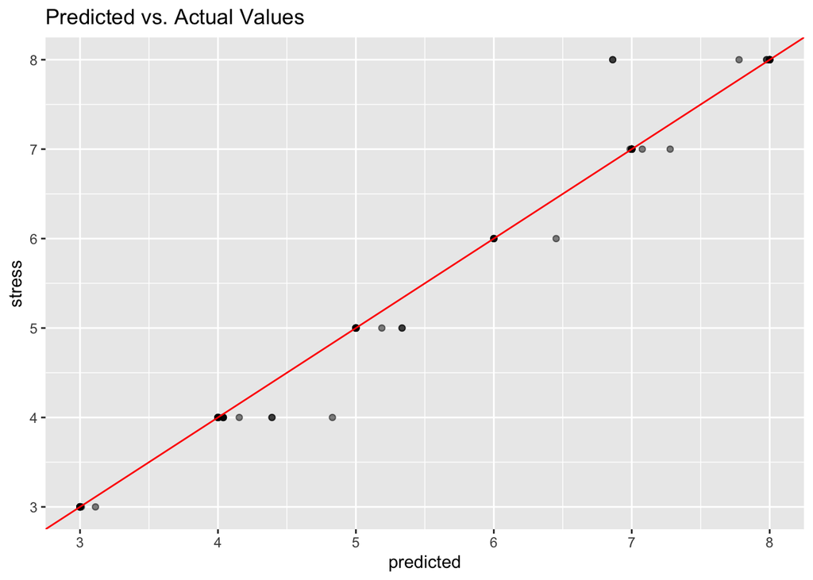

```r
# scatter plot
final_rf_model_test %>%
  ggplot(aes(x = .pred, y = stress)) +
  geom_point(alpha = 0.5) +
  geom_abline(color = 'red') +
  labs(title = 'Predicted vs. Actual Values',
       x = 'predicted')
```

This shows that most of the prediction points align with the line of best fit with only a few points straying a bit far from it, which further proves the random forest model’s accuracy on the testing set.

## Variable Importance Plot

Reflecting back on our correlation plot at the beginning, we can visualize which of our predictor variables contributed the most to the final model testing process.

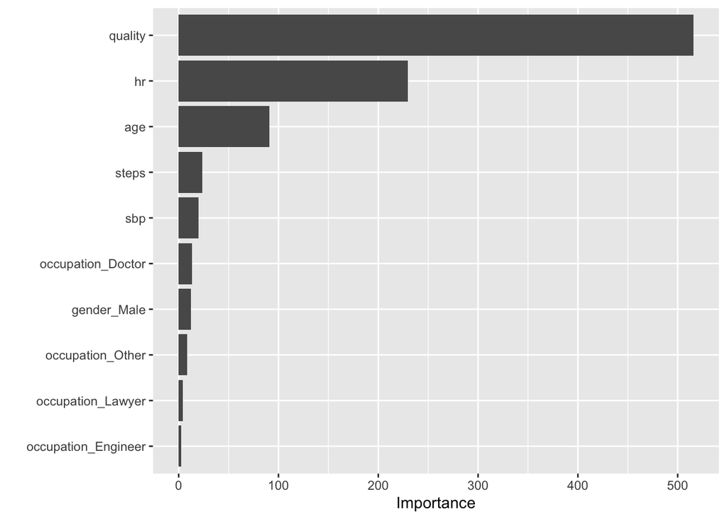

```r
# variable importance plot
vip(final_rf_model)
```

As expected from our first look at the correlation plot, `quality` has the greatest importance in predicting `stress`, followed by `hr` and `age`. The rest of the predictors after do not have nearly as much importance.

# Conclusion

After processing our data, fitting it into several models, and analyzing our results, we can conclude that the best model to predict our target variable `stress` is random forest by a pretty good margin. Ridge regression performed the worst significantly by almost doubling the rmse of random forest. One improvement I would make for this project would be to include the r-squared value alongside the rmse for each model as it would provide insight into the variance of the models. I would also try to incorporate other models such as support vector machines and boosted trees that could potentially outperform random forest.

There are some what-if questions that I still have. In the step deciding which variables to include and exclude due to high correlation between some variables, I do wonder if there is a more optimal combination of predictor variables especially since I chose to keep all the categorical predictor variables in the recipe. As for our target variable, I initially meant to use `quality` which did not have a good distribution but I am curious how the models would have performed predicting that variable instead. If I had the chance to repeat this project, I would most likely choose a non synthetic data set for a more authentic and real collection of information to work with. Overall, this was quite challenging in testing my ability to apply the resources I’ve been given, but it was a great opportunity to experience working on a full independent project.